# IODS week6 exercises

Sina Hulkkonen

12/8/2018

*Describe the work you have done this week and summarize your learning.*

I’ve returned to my clinical work, so I didn’t make it to the lectures and had minimal time for these exercises. I did all the DataCamp exercises.

At first, I copied the code from datawrangling exercise to get the long forms of these datasets:

```r
library(tidyr)
library(dplyr)
```

```r
library(ggplot2)

#loading he datasets BPRS and RATS
BPRS <- read.table("https://raw.githubusercontent.com/KimmoVehkalahti/MABS/master/Examples/data/BPRS.txt", sep  =" ", header = T)
RATS <- read.table("https://raw.githubusercontent.com/KimmoVehkalahti/MABS/master/Examples/data/rats.txt", header = TRUE, sep = '\t')
#both datasets include study IDs, and the participants have been divided into categories by treatment (BPRS) and group (RATS)
#converting categorical variables into factors
BPRS$treatment <- factor(BPRS$treatment)
RATS$Group <- factor(RATS$Group)
RATS$ID <- factor(RATS$ID)

##BPRS
#convert to long form
BPRSL <-  BPRS %>% gather(key = weeks, value = bprs, -treatment, -subject)
#extract the week number
BPRSL <-  BPRSL %>% dplyr::mutate(week = as.integer(substr(weeks,5,5)))
##RATS
# Convert data to long form & add Time variable
RATSL <- RATS %>%
  gather(key = WD, value = Weight, -ID, -Group) %>%
  mutate(Time = as.integer(substr(WD,3,4)))
```

## Analysis for RATS (MABS chapter 8)

# Looking at the data I wrangled before

```r
summary(RATSL)
```

```
##        ID      Group       WD                Weight           Time
##  1      : 11   1:88   Length:176         Min.   :225.0   Min.   : 1.00
##  2      : 11   2:44   Class :character   1st Qu.:267.0   1st Qu.:15.00
##  3      : 11   3:44   Mode  :character   Median :344.5   Median :36.00
##  4      : 11                             Mean   :384.5   Mean   :33.55
##  5      : 11                             3rd Qu.:511.2   3rd Qu.:50.00
##  6      : 11                             Max.   :628.0   Max.   :64.00
##  (Other):110
```

```r
str(RATSL)
```

```
## 'data.frame':    176 obs. of  5 variables:
##  $ ID    : Factor w/ 16 levels "1","2","3","4",..: 1 2 3 4 5 6 7 8 9 10 ...
##  $ Group : Factor w/ 3 levels "1","2","3": 1 1 1 1 1 1 1 1 2 2 ...
##  $ WD    : chr  "WD1" "WD1" "WD1" "WD1" ...
##  $ Weight: int  240 225 245 260 255 260 275 245 410 405 ...
##  $ Time  : int  1 1 1 1 1 1 1 1 1 1 ...
```

```r
glimpse(RATSL)
```

```
## Observations: 176
## Variables: 5
## $ ID     <fct> 1, 2, 3, 4, 5, 6, 7, 8, 9, 10, 11, 12, 13, 14, 15, 16, ...
## $ Group  <fct> 1, 1, 1, 1, 1, 1, 1, 1, 2, 2, 2, 2, 3, 3, 3, 3, 1, 1, 1...
## $ WD     <chr> "WD1", "WD1", "WD1", "WD1", "WD1", "WD1", "WD1", "WD1",...
## $ Weight <int> 240, 225, 245, 260, 255, 260, 275, 245, 410, 405, 445, ...
## $ Time   <int> 1, 1, 1, 1, 1, 1, 1, 1, 1, 1, 1, 1, 1, 1, 1, 1, 8, 8, 8...
```

The RATS data contains information on rats gaining weight on specific diet. The three groups were put on different diets, and each animal’s body weight (grams) was recorded repeatedly (approximately weekly, except in week seven when two recordings were taken) over a 9-week period.

# Graphical Displays of Longitudinal Data RATSL

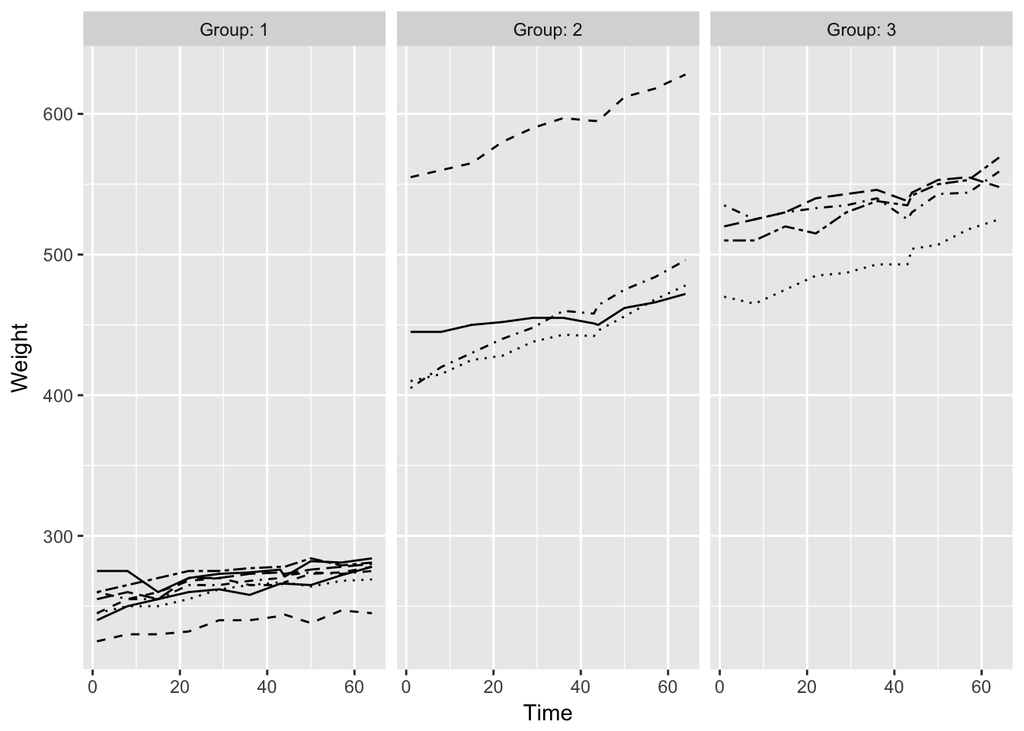

```r
library(ggplot2)

# Draw the plot
ggplot(RATSL, aes(x = Time, y = Weight, linetype = ID)) +
  geom_line() +
  scale_linetype_manual(values = rep(1:10, times=4)) +
  facet_grid(. ~ Group, labeller = label_both) +
  theme(legend.position = "none") +
  scale_y_continuous(limits = c(min(RATSL$Weight), max(RATSL$Weight)))
```

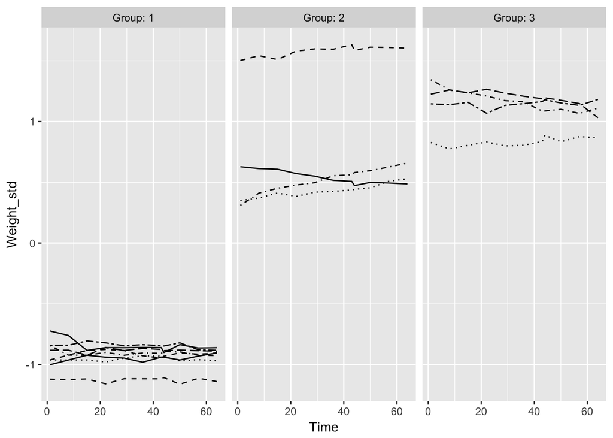

```r
# Standardise the variable Weight
RATSL <- RATSL %>%
  group_by(Time) %>%
  mutate(Weight_std = (Weight - mean(Weight))/sd(Weight) ) %>%
  ungroup()

# Draw the plot with scaled weights
ggplot(RATSL, aes(x = Time, y = Weight_std, linetype = ID)) +
  geom_line() +
  scale_linetype_manual(values = rep(1:10, times=4)) +
  facet_grid(. ~ Group, labeller = label_both) +
  theme(legend.position = "none") +
  scale_y_continuous(limits = c(min(RATSL$Weight_std), max(RATSL$Weight_std)))
```

Here in the first pictures we see, how the weights of the rats in each group developed by time. In the second picture, the weights of the rats are standardized, since they are different in the beginning. This enables us to compare the change they had over time.

# Summary Measure Analysis of Longitudinal Data for RATSL

```r
# Number of weeks, baseline (week 0) included
n <- RATSL$Time %>% unique() %>% length()

# Summary data with mean and standard error of bprs by treatment and week
RATSS <- RATSL %>%
  group_by(Group, Time) %>%
  summarise( mean = mean(Weight), se = sd(Weight)/sqrt(n) ) %>%
  ungroup()

# Glimpse the data
glimpse(RATSS)
```

```
## Observations: 33
## Variables: 4
## $ Group <fct> 1, 1, 1, 1, 1, 1, 1, 1, 1, 1, 1, 2, 2, 2, 2, 2, 2, 2, 2,...
## $ Time  <int> 1, 8, 15, 22, 29, 36, 43, 44, 50, 57, 64, 1, 8, 15, 22, ...
## $ mean  <dbl> 250.625, 255.000, 254.375, 261.875, 264.625, 265.000, 26...
## $ se    <dbl> 4.589478, 3.947710, 3.460116, 4.100800, 3.333956, 3.5529...
```

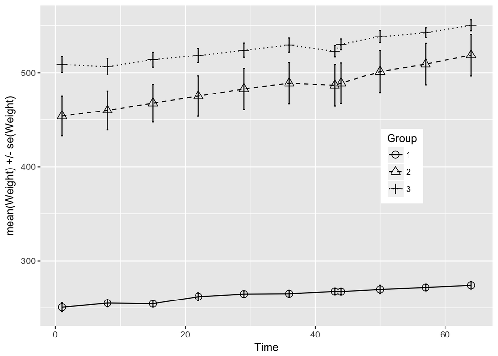

```r
# Plot the mean profiles
ggplot(RATSS, aes(x = Time, y = mean, linetype = Group, shape = Group)) +
  geom_line() +
  scale_linetype_manual(values = c(1,2,3)) +
  geom_point(size=3) +
  scale_shape_manual(values = c(1,2,3)) +
  geom_errorbar(aes(ymin = mean - se, ymax = mean + se, linetype="1"), width=0.3) +
  theme(legend.position = c(0.8,0.5)) +
  scale_y_continuous(name = "mean(Weight) +/- se(Weight)")
```

# Applying the Summary Measure Approach

```r
# Create a summary data by treatment and subject with mean as the summary variable (ignoring baseline week 0).
RATSLS <- RATSL %>%
  filter(Time > 0) %>%
  group_by(Group, ID) %>%
  summarise( mean=mean(Weight) ) %>%
  ungroup()

glimpse(RATSLS)
```

```
## Observations: 16
## Variables: 3
## $ Group <fct> 1, 1, 1, 1, 1, 1, 1, 1, 2, 2, 2, 2, 3, 3, 3, 3
## $ ID    <fct> 1, 2, 3, 4, 5, 6, 7, 8, 9, 10, 11, 12, 13, 14, 15, 16
## $ mean  <dbl> 261.0909, 237.6364, 260.1818, 266.5455, 269.4545, 274.72...
```

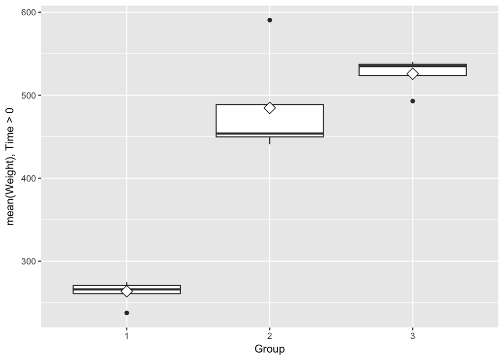

```r
# Draw a boxplot of the mean versus treatment
ggplot(RATSLS, aes(x = Group, y = mean)) +
  geom_boxplot() +
  stat_summary(fun.y = "mean", geom = "point", shape=23, size=4, fill = "white") +
  scale_y_continuous(name = "mean(Weight), Time > 0")
```

```r
#Cannot do T-test, since group has three levels, lets do chi-squred instead
chisq.test(RATSLS$Group, RATSLS$mean)
```

```
##
##  Pearson's Chi-squared test
##
## data:  RATSLS$Group and RATSLS$mean
## X-squared = 32, df = 30, p-value = 0.3675
```

# Incorporating Pre-Treatment Outcome Values into the Summary Measure Approach

```r
# Add the baseline from the original data as a new variable to the summary data
RATSLS <- RATSLS %>%
  mutate(baseline = RATS$WD1)

# Fit the linear model with the mean as the response
fit <- lm(mean ~ baseline + Group, data = RATSLS)

# Compute the analysis of variance table for the fitted model with anova()
anova(fit)
```

```
## Analysis of Variance Table
##
## Response: mean
##           Df Sum Sq Mean Sq   F value    Pr(>F)
## baseline   1 252125  252125 2237.0655 5.217e-15 ***
## Group      2    726     363    3.2219   0.07586 .
## Residuals 12   1352     113
## ---
## Signif. codes:  0 '***' 0.001 '**' 0.01 '*' 0.05 '.' 0.1 ' ' 1
```

Baseline measurements of the outcome variable in a longitudinal study are often correlated with the chosen summary measure and using such measures in the analysis can often lead to substantial gains in precision when used appropriately as a covariate in an analysis of covariance. Here we see, that te baseline (the weight of the rats in the beginning of the study) is correlated with mean weight gain in the follow-up. This means, that if the groups differ by weight in the beginning, the results might be biased.

## Analysis for BPRS (MABS chapter 9)

# Looking at the data I wrangled before

```r
summary(BPRSL)
```

```
##  treatment    subject         weeks                bprs            week
##  1:180     Min.   : 1.00   Length:360         Min.   :18.00   Min.   :0
##  2:180     1st Qu.: 5.75   Class :character   1st Qu.:27.00   1st Qu.:2
##            Median :10.50   Mode  :character   Median :35.00   Median :4
##            Mean   :10.50                      Mean   :37.66   Mean   :4
##            3rd Qu.:15.25                      3rd Qu.:43.00   3rd Qu.:6
##            Max.   :20.00                      Max.   :95.00   Max.   :8
```

```r
str(BPRSL)
```

```
## 'data.frame':    360 obs. of  5 variables:
##  $ treatment: Factor w/ 2 levels "1","2": 1 1 1 1 1 1 1 1 1 1 ...
##  $ subject  : int  1 2 3 4 5 6 7 8 9 10 ...
##  $ weeks    : chr  "week0" "week0" "week0" "week0" ...
##  $ bprs     : int  42 58 54 55 72 48 71 30 41 57 ...
##  $ week     : int  0 0 0 0 0 0 0 0 0 0 ...
```

```r
glimpse(BPRSL)
```

```
## Observations: 360
## Variables: 5
## $ treatment <fct> 1, 1, 1, 1, 1, 1, 1, 1, 1, 1, 1, 1, 1, 1, 1, 1, 1, 1...
## $ subject   <int> 1, 2, 3, 4, 5, 6, 7, 8, 9, 10, 11, 12, 13, 14, 15, 1...
## $ weeks     <chr> "week0", "week0", "week0", "week0", "week0", "week0"...
## $ bprs      <int> 42, 58, 54, 55, 72, 48, 71, 30, 41, 57, 30, 55, 36, ...
## $ week      <int> 0, 0, 0, 0, 0, 0, 0, 0, 0, 0, 0, 0, 0, 0, 0, 0, 0, 0...
```

BPRS data contains information of 40 male subjects were randomly assigned to one of two treatment groups and each subject was rated on the brief psychiatric rating scale (BPRS) measured before treatment began (week 0) and then at weekly intervals for eight weeks. The BPRS assesses the level of 18 symptom constructs such as hostility, suspiciousness, hallucinations and grandiosity; each of these is rated from one (not present) to seven (extremely severe). The scale is used to evaluate patients suspected of having schizophrenia.

# Linear mixed effect models for repeated measures data

Please see the data wrangling part! I converted BPRS into longitudinal form previously.

# Fitting the Independence Model to the BPRSL Data

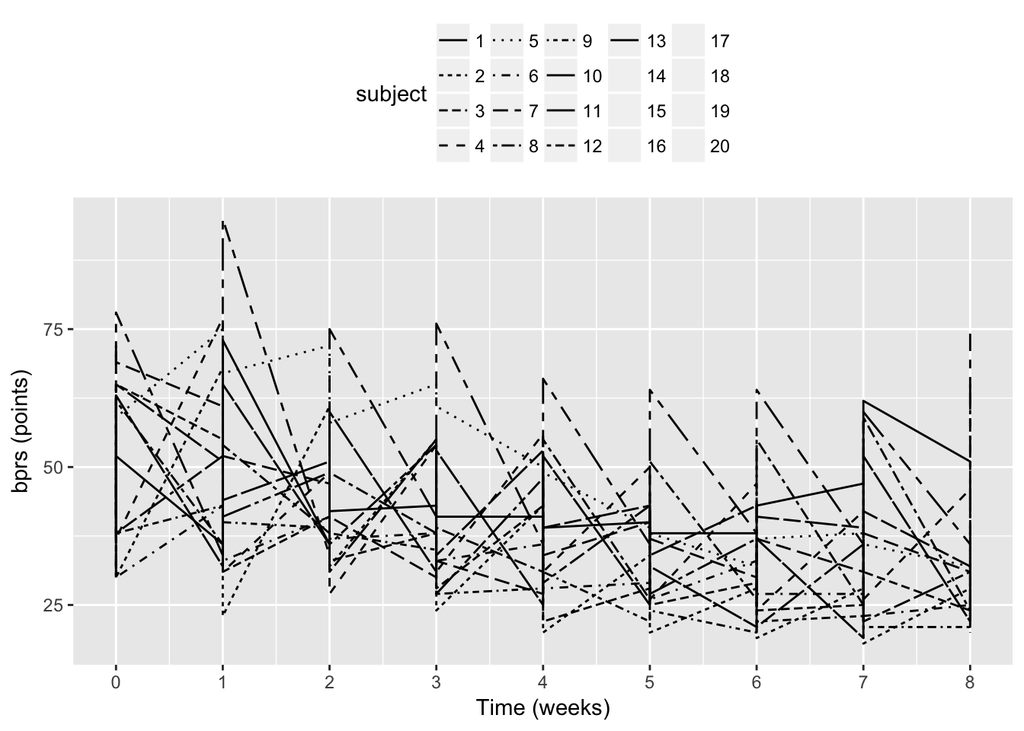

```r
#For this plot to succeed, I have t make new factors
BPRSL$treatment<-factor(BPRSL$treatment)
BPRSL$subject<-factor(BPRSL$subject)

# Plot the BPRSL data
#p<-ggplot(BPRSL, aes(x = week, y = bprs, group = subject))
#p1<- p+geom_line(aes(linetype = treatment))
#p2<-p1+ scale_x_continuous(name = "Time (weeks)", breaks = seq(0, 8, 1))
#p3<-p2+scale_y_continuous(name = "bprs (points)")
#p4<-p3+theme(legend.position = "top")
#help("geom_line")
#p4

p<-ggplot(BPRSL, aes(x = week, y = bprs, group = subject))
p1<- p+geom_line(aes(linetype = subject))
p2<-p1+ scale_x_continuous(name = "Time (weeks)", breaks = seq(0, 8, 1))
p3<-p2+scale_y_continuous(name = "bprs (points)")
p4<-p3+theme(legend.position = "top")
p4
```

```r
#ggplot(BPRSL, aes(x = week, y = bprs, group = subject)) +geom_line(aes(linetype = treatment)) + scale_x_continuous(name = "Time (weeks)", breaks = seq(0, 8, 1))+scale_y_continuous(name = "bprs (points)")+theme(legend.position = "top")
```

Here we ignore that there are multiple observations belonging to one individual (independence model). For some reason, the command ends up in error. I was able t draw a plot where single individuals bprs scores are shown week by week.